# Happiness Levels

## Charts

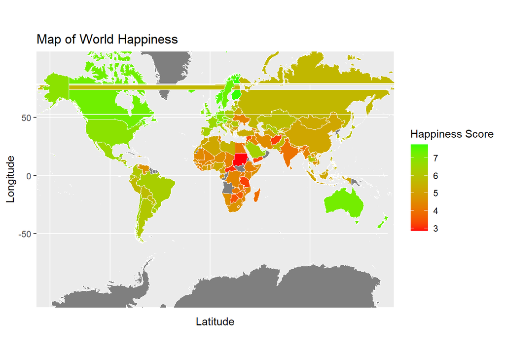

Chart 1 is meant to show which regions of the world are the happiest. People in North America and Western Europe appear to be the happiest. This chart was included for a visualization of where people are the least and most happy.

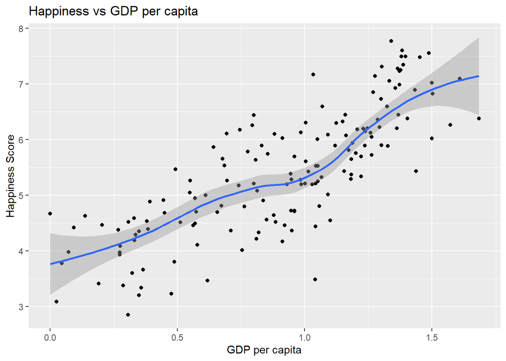

Chart 2 depicts the relationship between GDP per capita and happiness. This chart was included to test the popular phrase “Money can’t buy happiness”. This chart reveals that increases in GDP per capita does improve the overall happiness of a country. However, there are large variances, where some countries have nearly the same GDP per capita but have large disparities in happiness.

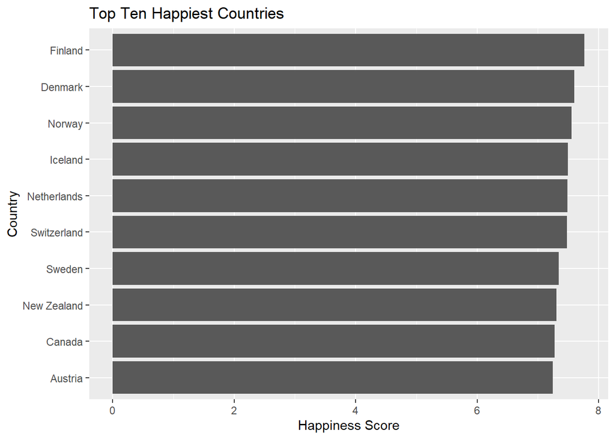

Chart 3 shows the happiest places in the world. The Scandinavian countries appear to be the happiest. This chart was included to highlight the countries with the highest happiness ratings.